# Лабораторная работа №4

Включение графики в LaTeX

Ван Яо

1132259420@rudn.ru

Российский университет дружбы народов

2026-10-17

# Информация

## Докладчик

- Ван Яо
- Студент ФФМиЕН
- Российский университет дружбы народов им. П. Лумумбы
- 1132259420@rudn.ru

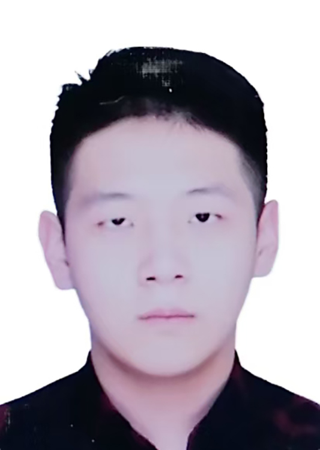

# Вводная часть

## Цели и задачи

- Цель:
  - изучить способы включения графики в документ LaTeX
- Задачи:
  - базовые команды пакета `graphicx`
  - изменение параметров (размер, обрезка, поворот)
  - плавающие объекты (floats) и их размещение
  - механизм перекрёстных ссылок (`\label` и `\ref`)
  - хранение графики в подкаталогах

## Пакет graphicx

- Для вставки используется пакет `graphicx` и команда `\includegraphics`
- Поддерживаются форматы: EPS, PNG, JPG, PDF
- Управление размером: `width`, `height`, `scale` (с сохранением пропорций)
- Обрезка (`clip`, `trim`) и поворот (`angle`)

# Ход выполнения работы

## Базовое включение и размеры

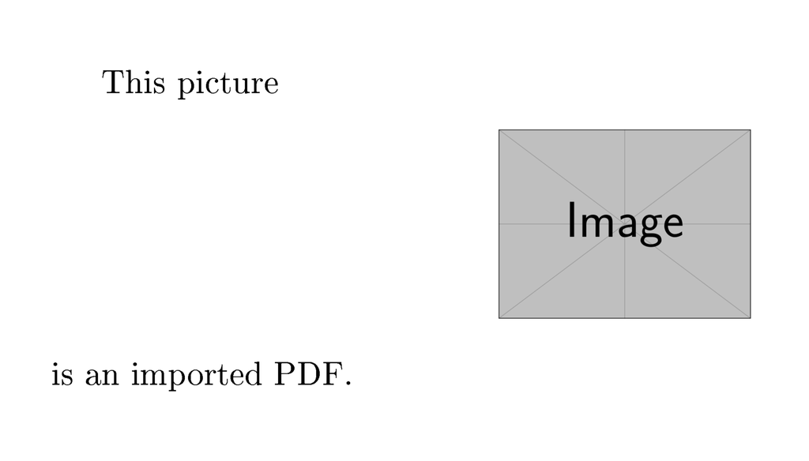

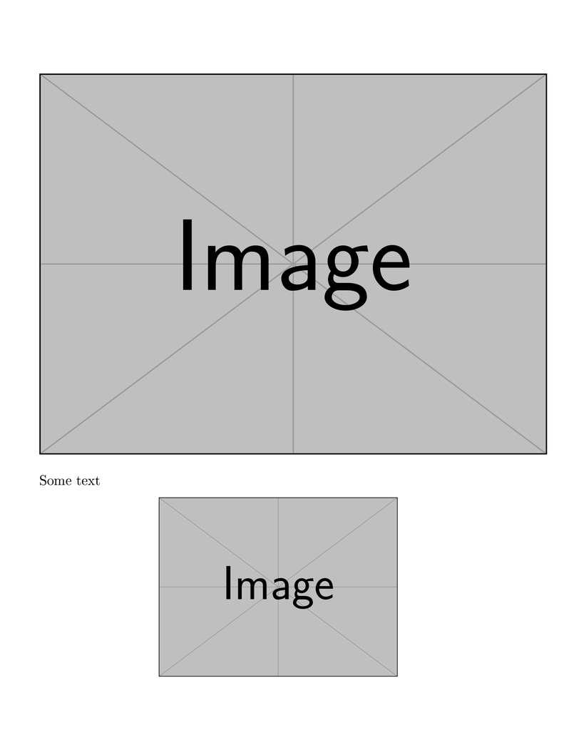

```latex
\usepackage{graphicx}
\includegraphics[height=2cm]{example-image}
```

## Обрезка и поворот

- Обрезка с помощью `clip` и `trim`
- Поворот через параметр `angle`

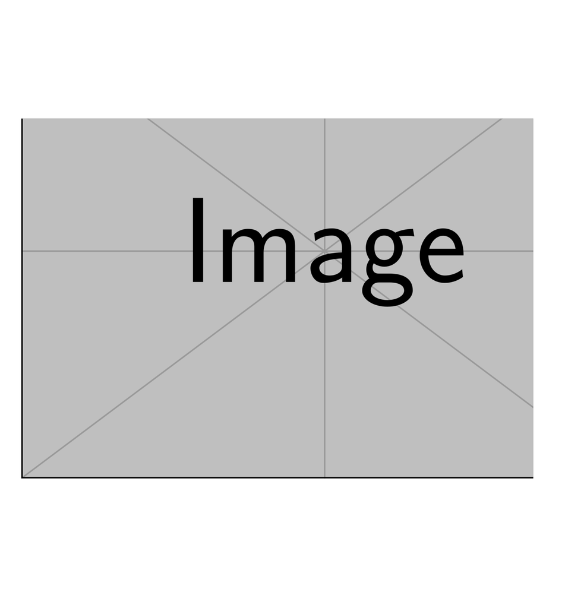

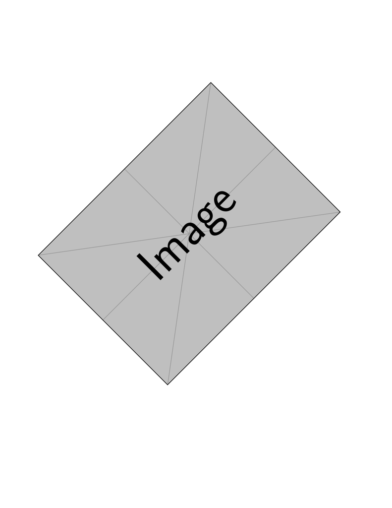

```latex
\includegraphics[angle=45, width=0.4\textwidth]{example-image}
```

## Плавающие объекты (floats)

- Изображения обычно помещают в окружение `figure`
- LaTeX сам оптимизирует положение объекта
- Параметры размещения: `h` (here), `t` (top), `b` (bottom), `p` (page)

```latex
\begin{figure}[ht]
\centering
\includegraphics[width=0.5\textwidth]{example-image}
\caption{An example image}
\end{figure}
```

[figure not shown]

## Строгое размещение и пользовательские floats

- Пакет `float` и параметр `[H]` для строгого размещения
- Пакет `trivfloat` для создания новых типов окружений

[figure not shown]

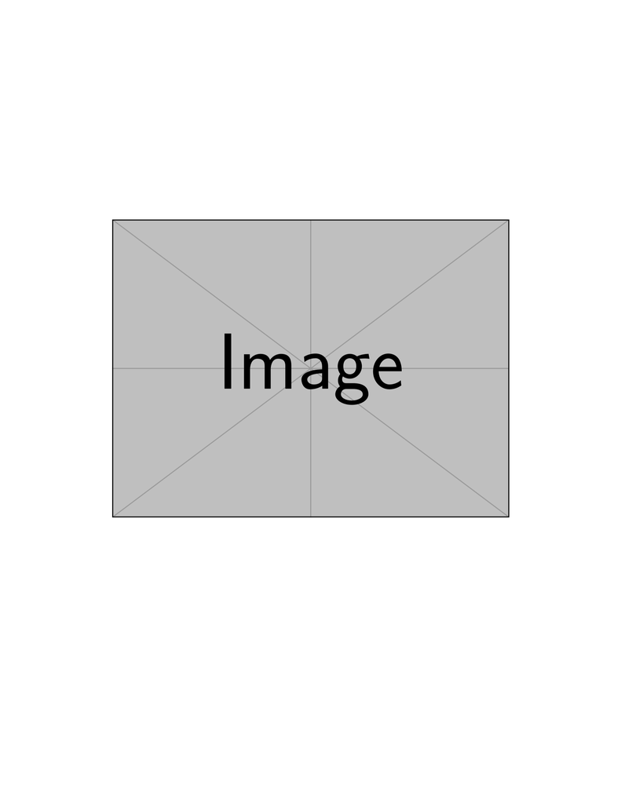

```latex
\usepackage{float}
\begin{figure}[H] ...
```

## Пути к файлам

- Именование файлов без пробелов
- Настройка путей поиска с помощью `\graphicspath`

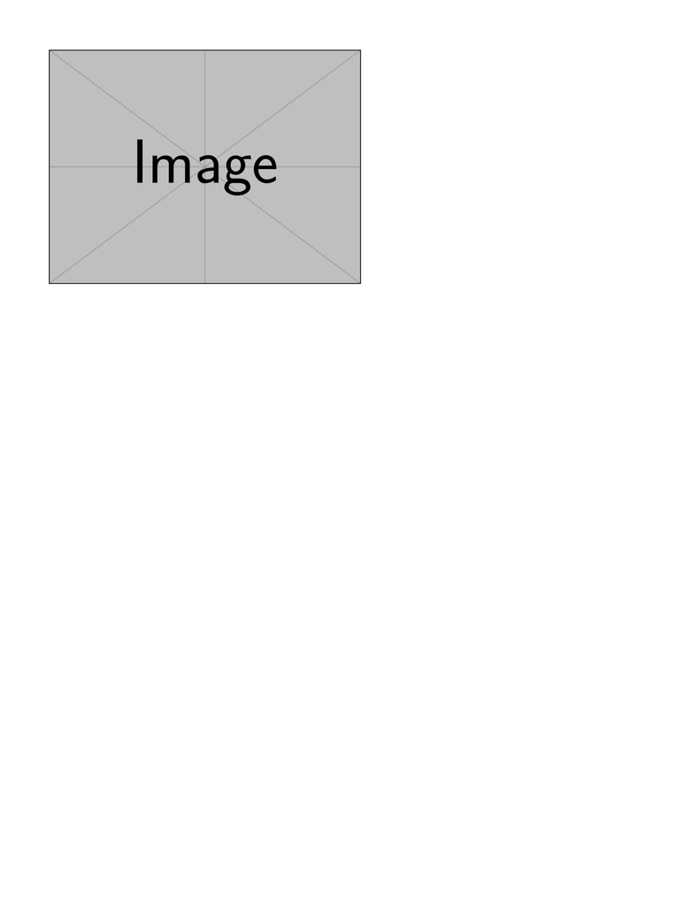

```latex
\graphicspath{{figs/}{pics/}}
```

## Перекрёстные ссылки

- Использование `\label` и `\ref`
- Важно: требуется двойная компиляция для обновления ссылок
- `hyperref` делает ссылки кликабельными

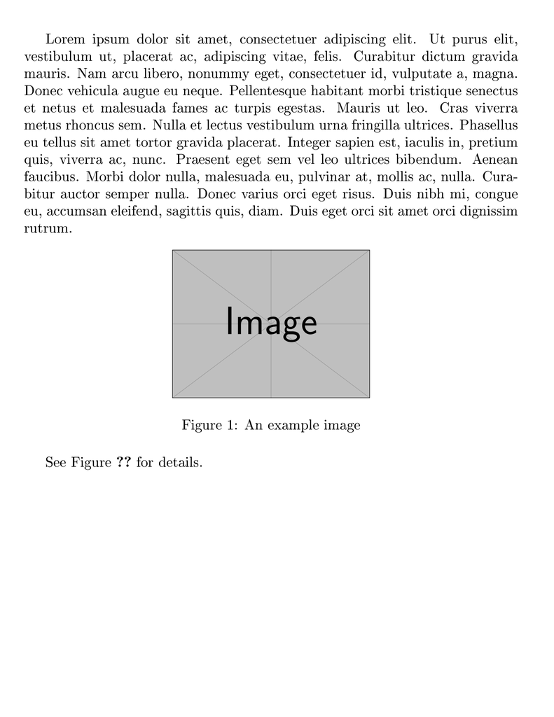

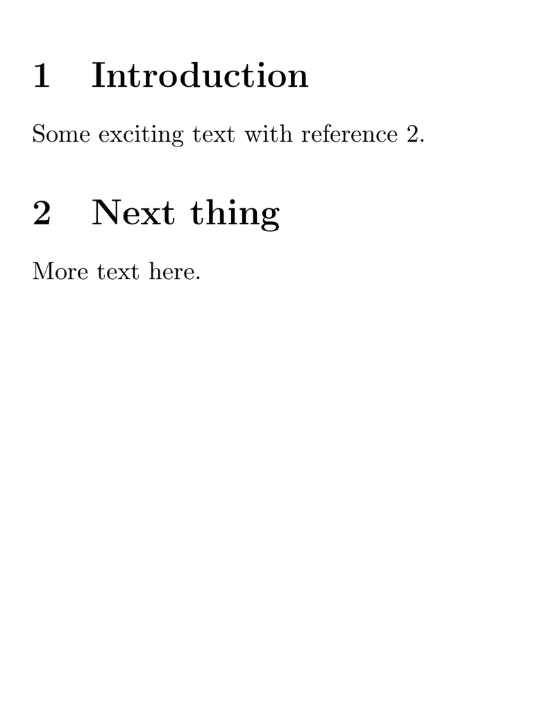

```latex
\label{fig:example}
See Figure~\ref{fig:example}
```

# Заключение